**DAB401 – Final Group Project**

# **Financial Analysis of a Business**

Course: DAB401 Due Date: April 5, 2026 Submission Type: Group Project - Group 8

## **Instructor:**

- **Prof. PRATIK BEDI**

## **Contributors:**

- **Truc Anh Nguyen - 0873760**

CONTENTS:

1. Apple Stock Price Trend
2. CAPM and Cost of Equity – Apple vs. S&P 500
3. Free Cash Flow (FCF)
4. Valuation (WACC & Intrinsic Value): WACC Sensitivity Analysis – Intrinsic Value per Share
5. Monte Carlo Simulation - 100 Simulations for Next 30 Days - Present graphical output - Interpret mean forecast and risk range
6. FB Prophet Forecast – Apple Stock (Next 30 Days)
7. TRADE SIGNALS - MOVING AVERAGE

The aim is to assess Apple's profitability, liquidity, growth potential, and investment attractiveness from a financial analyst’s perspective.

```python
# Import libraries
import yfinance as yf
import pandas as pd
import numpy as np
import matplotlib.pyplot as plt
from scipy.stats import linregress
import warnings
warnings.filterwarnings('ignore')
```

```python
import yfinance as yf
# Determine the time period
start_date = '2015-12-31'
end_date = '2025-12-31'
# Download data from yfinance
apple_df = yf.download('AAPL', start=start_date, end=end_date)
sp500_df = yf.download('^GSPC', start=start_date, end=end_date)
# Checking the columns
print("Apple columns:", apple_df.columns)
print("S&P500 columns:", sp500_df.columns)
# Get the adjusted price if the column exists
if 'Adj Close' in apple_df.columns:
    apple_close = apple_df['Adj Close']
else:
    apple_close = apple_df['Close']  # fallback

if 'Adj Close' in sp500_df.columns:
    sp500_close = sp500_df['Adj Close']
else:
    sp500_close = sp500_df['Close']  # fallback

print(apple_close.head())
print(sp500_close.head())
```

```
[*********************100%***********************]  1 of 1 completed
[*********************100%***********************]  1 of 1 completed
```

```
Apple columns: MultiIndex([( 'Close', 'AAPL'),
            (  'High', 'AAPL'),
            (   'Low', 'AAPL'),
            (  'Open', 'AAPL'),
            ('Volume', 'AAPL')],
           names=['Price', 'Ticker'])
S&P500 columns: MultiIndex([( 'Close', '^GSPC'),
            (  'High', '^GSPC'),
            (   'Low', '^GSPC'),
            (  'Open', '^GSPC'),
            ('Volume', '^GSPC')],
           names=['Price', 'Ticker'])
Ticker           AAPL
Date
2015-12-31  23.710676
2016-01-04  23.730946
2016-01-05  23.136261
2016-01-06  22.683498
2016-01-07  21.726154
Ticker            ^GSPC
Date
2015-12-31  2043.939941
2016-01-04  2012.660034
2016-01-05  2016.709961
2016-01-06  1990.260010
2016-01-07  1943.089966
```

## 1. Apple Stock Price Trend

This chart shows AAPL closing price over last one year, used to observe market performance, show the volatility and trends

```
[*********************100%***********************]  1 of 1 completed
[*********************100%***********************]  1 of 1 completed
```

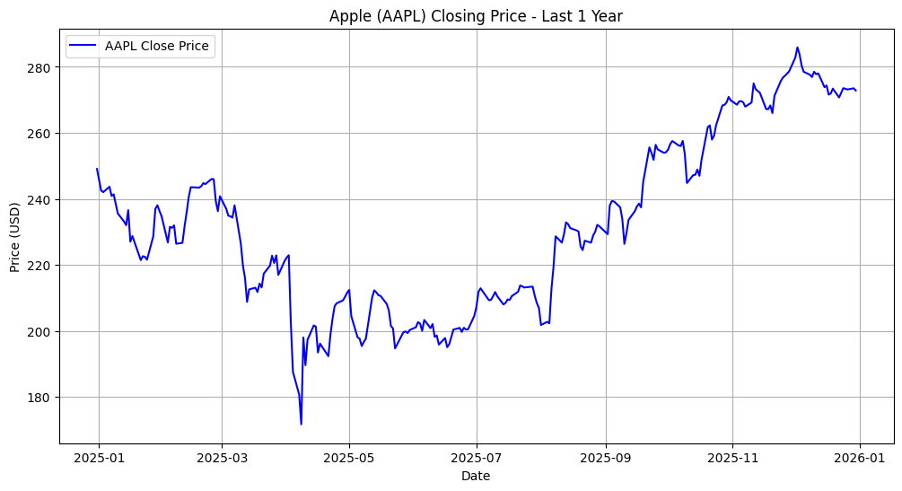

```python
# Determine the time period
start_date = '2024-12-31'
end_date = '2025-12-31'
# Download data from yfinance
apple_df_24_25 = yf.download('AAPL', start=start_date, end=end_date)
sp500_df_24_25 = yf.download('^GSPC', start=start_date, end=end_date)
# Get the closing price
apple_close_24_25 = apple_df_24_25['Close']
sp500_close_24_25 = sp500_df_24_25['Close']
plt.figure(figsize=(12,6))
plt.plot(apple_close_24_25, label='AAPL Close Price', color='blue')
plt.title('Apple (AAPL) Closing Price - Last 1 Year')
plt.xlabel('Date')
plt.ylabel('Price (USD)')
plt.grid(True)
plt.legend()
plt.show()
```

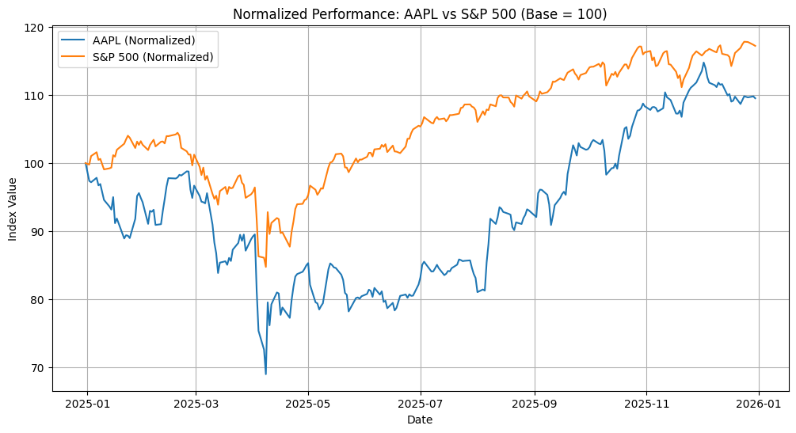

```python
# Normalize (base = 100)
apple_norm = apple_close_24_25 / apple_close_24_25.iloc[0] * 100
sp500_norm = sp500_close_24_25 / sp500_close_24_25.iloc[0] * 100

plt.figure(figsize=(12,6))

plt.plot(apple_norm, label='AAPL (Normalized)')
plt.plot(sp500_norm, label='S&P 500 (Normalized)')

plt.title('Normalized Performance: AAPL vs S&P 500 (Base = 100)')
plt.xlabel('Date')
plt.ylabel('Index Value')
plt.legend()
plt.grid(True)

plt.show()
```

## 2. CAPM and Cost of Equity – Apple vs. S&P 500

In this part, we calculate **Apple’s Beta** using the **Capital Asset Pricing Model (CAPM)** framework.

- Beta is derived via **linear regression** of Apple’s daily returns against the **S&P 500 index returns**.
- AAPL’s Beta measures its **systematic risk** relative to the overall market.
- The resulting Beta value indicates how sensitive Apple’s stock is to market movements:
  - **Beta > 1** → More volatile than the market
  - **Beta < 1** → Less volatile

> In this case, the calculated **Beta ≈ 1.2072**, implying:
- Beta = 1.2 → Apple's volatility is about 20% higher than the market.
- If the S&P 500 rises 10%, Apple could rise about 12%.
- If the market falls, Apple also falls faster → higher systemic risk.

```python
# Calculate daily yield
aapl_returns = apple_close.pct_change().dropna()
sp500_returns = sp500_close.pct_change().dropna()
#Combine data into a DataFrame
df = pd.concat([aapl_returns, sp500_returns], axis=1)
df.columns = ['AAPL_Returns', 'SP500_Returns']
df.dropna(inplace=True)
# Calculate Beta using linear regression
slope, intercept, r_value, p_value, std_err = linregress(df['SP500_Returns'], df['AAPL_Returns'])
beta = slope
print(f"Beta = {beta:.4f}")
```

```
Beta = 1.2072
```

### Beta Visualization via Regression Plot

The scatter plot below visualizes the relationship between Apple’s returns and the S&P 500’s returns. The red line represents the **regression line**, whose slope equals **Apple’s Beta**.

- Each point represents a pair of daily returns (AAPL vs. SP500).
- A clear positive slope indicates that Apple’s returns are positively correlated with the market.
- The regression line provides a visual confirmation of the Beta value computed earlier.

> This regression plot supports the **CAPM-based risk assessment** and enhances the understanding of Apple's market sensitivity.

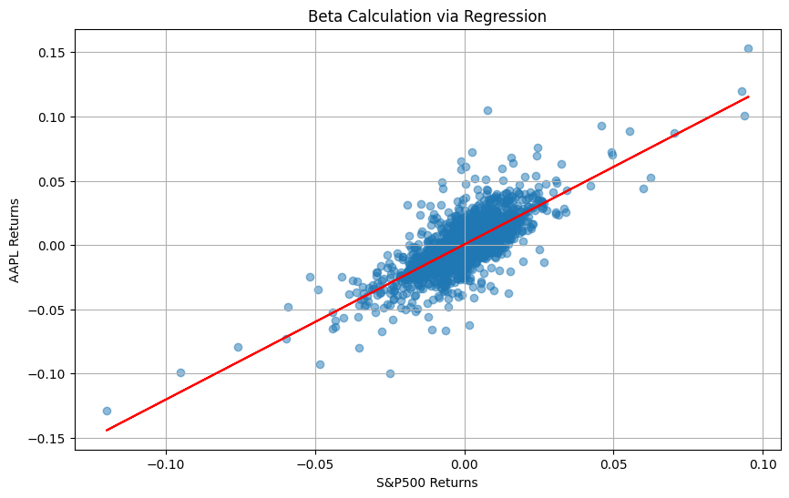

```python
# Regression Plot
plt.figure(figsize=(10,6))
plt.scatter(df['SP500_Returns'], df['AAPL_Returns'], alpha=0.5)
plt.plot(df['SP500_Returns'], intercept + beta * df['SP500_Returns'], color='red')
plt.title('Beta Calculation via Regression')
plt.xlabel('S&P500 Returns')
plt.ylabel('AAPL Returns')
plt.grid(True)
plt.show()
```

```
Outliers detected:
            AAPL_Returns  SP500_Returns
Date
2020-03-13      0.119809       0.092871
2020-03-16     -0.128647      -0.119841
2020-03-24      0.100325       0.093828
2020-07-31      0.104689       0.007671
2025-04-09      0.153288       0.095154
```

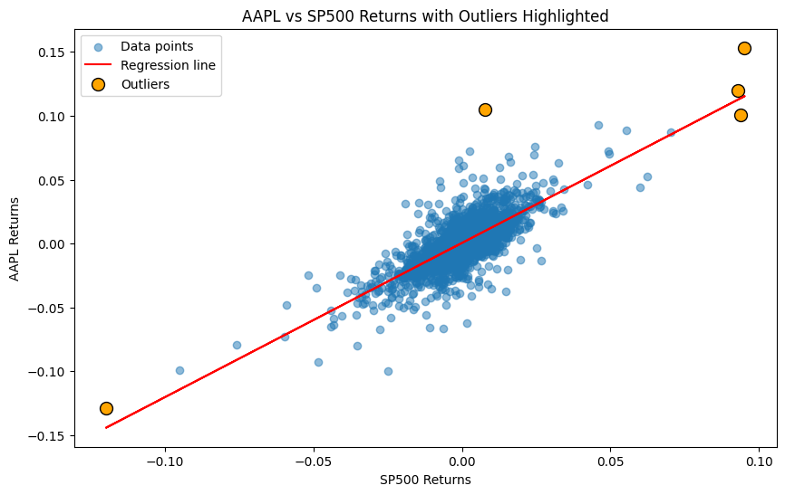

```python
import matplotlib.pyplot as plt

# Asume the outlier is that the APPL return exceed ±10%
threshold = 0.10

# Filter outlier
outliers = df[(df['AAPL_Returns'] > threshold) | (df['AAPL_Returns'] < -threshold)]

# Print date and value of outlier
print("Outliers detected:")
print(outliers)

# Draw scatter plot
plt.figure(figsize=(10,6))
plt.scatter(df['SP500_Returns'], df['AAPL_Returns'], alpha=0.5, label='Data points')

# Draw regression
plt.plot(df['SP500_Returns'], intercept + beta * df['SP500_Returns'], color='red', label='Regression line')

# Mark outlier on plot
plt.scatter(outliers['SP500_Returns'], outliers['AAPL_Returns'], color='orange', edgecolor='black', s=100, label='Outliers')

plt.title('AAPL vs SP500 Returns with Outliers Highlighted')
plt.xlabel('SP500 Returns')
plt.ylabel('AAPL Returns')
plt.legend()
plt.show()
```

Outlier Explanation:

On April 9, 2025, Apple (AAPL) experienced an unusually high daily return of +15.33%, compared to the S&P 500 increase of +9.51%. This outlier is attributed to the official announcement that the U.S. government would postpone new trade tariffs for 90 days, which significantly eased market concerns over production costs and global supply chain risks, especially benefiting large tech companies like Apple.

### CAPM-Based Cost of Equity (ROE)

Using the CAPM model, we calculate Apple’s **cost of equity** based on data from the *Apple 2025 Annual Report* Excel file, from U.S. Department of Treasury – Daily Treasury Yield Curve Rates and yfinance:

- Risk-free rate = 0.0269 → 2.69%/year (10-year US Treasury yield - average 10 year start='2015-12-31', end='2025-12-31')
- Market return = 13.85% (S&P500 10-year average: start='2015-12-31', end='2025-12-31')
- Beta ≈ 1.2 (calculated from historical regression of AAPL vs. S&P 500 returns)

A return on equity (ROE) of 16.16% per year is the level of return that investors require for investing in Apple stock.

The result (16.16%) represents the **expected return required by equity investors**, and is used to estimate the cost of equity in valuation models such as WACC or DCF.

```python
# U.S. Department of Treasury – Daily Treasury Yield Curve Rates
import yfinance as yf
# Download US 10-Year Treasury Yield Data
tnx = yf.download('^TNX', start='2015-12-31', end='2025-12-31')
# Calculate the average risk-free interest rate over the period
Rf = tnx['Close'].mean()/100
print(Rf)
```

```
[*********************100%***********************]  1 of 1 completed
```

```
Ticker
^TNX    0.026915
dtype: float64
```

```python
# Get Market return from actual data.
# Download S&P 500 data from 2015 to 2025
sp500_df = yf.download('^GSPC', start='2015-12-31', end='2025-12-31')
sp500_close = sp500_df['Close']
# Calculate daily yield
sp500_returns = sp500_close.pct_change().dropna()
# Calculate the expected annual market return.
Rm = sp500_returns.mean().iloc[0] * 252  # is the number of trading days/year
print(f"Expected market return (annualized) = {Rm:.2%}")
```

```
[*********************100%***********************]  1 of 1 completed
```

```
Expected market return (annualized) = 13.85%
```

```python
# Calculate ROE using CAPM
risk_free_rate = 0.0269
market_return = 0.1385
roe_capm = risk_free_rate + beta * (market_return - risk_free_rate)
print(f"ROE using CAPM = {roe_capm:.2%}")
```

```
ROE using CAPM = 16.16%
```

## 3. Free Cash Flow (FCF)

Free Cash Flow (FCF) represents the cash a company generates from its operations after accounting for capital expenditures. It indicates the cash available to reinvest in the business, pay dividends, reduce debt, or pursue growth opportunities.

```
FCF 5 years (Million USD):
2021         NaN
2022    111443.0
2023     99584.0
2024    108807.0
2025     98767.0
Name: Free Cash Flow, dtype: float64
```

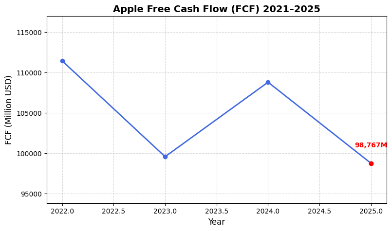

```python
# Step 1: Get cashflow data

ticker = yf.Ticker("AAPL")
cashflow = ticker.cashflow.T  # transpose year into index

# Step 2: Get Free Cash Flow (FCF)
fcf = cashflow['Free Cash Flow']

# Convert index into year (int)
fcf.index = fcf.index.year

# Step 3: Filter 5 latest years
last_5_years = fcf.index.sort_values()[-5:]
fcf_5y = fcf.loc[last_5_years]

# Step 4: Convert to Million USD
fcf_5y_million = fcf_5y / 1e6

# Step 5: Print for check
print("FCF 5 years (Million USD):")
print(fcf_5y_million)

# Step 6: Plot chart
plt.figure(figsize=(9,5))
plt.plot(fcf_5y_million.index, fcf_5y_million.values, marker='o', color='royalblue', linewidth=2)

# Highlight newest year
plt.scatter(fcf_5y_million.index.max(), fcf_5y_million.values[-1], color='red', zorder=5)
plt.text(fcf_5y_million.index.max(), fcf_5y_million.values[-1]+2000,  # offset để không chạm marker
         f"{fcf_5y_million.values[-1]:,.0f}M", ha='center', color='red', fontsize=10, fontweight='bold')

# Title, labels, grid
plt.title(f"Apple Free Cash Flow (FCF) {fcf_5y_million.index.min()}–{fcf_5y_million.index.max()}",
          fontsize=14, fontweight='bold')
plt.xlabel("Year", fontsize=12)
plt.ylabel("FCF (Million USD)", fontsize=12)
plt.grid(True, linestyle='--', alpha=0.5)

# Step 7: Adjust Y-axis for wider range
y_min = fcf_5y_million.min() * 0.95  # 5% below min
y_max = fcf_5y_million.max() * 1.05  # 5% above max
plt.ylim(y_min, y_max)

plt.show()
```

## 4. Valuation (WACC & Intrinsic Value): WACC Sensitivity Analysis – Intrinsic Value per Share

This table shows how Apple’s **intrinsic value per share** changes under different WACC assumptions (6%–20%).

Free Cash Flow (FCF) = 98,767 million USD

Shares Outstanding = 15,015 million shares

- Firm Value - Intrinsic Firm Value = Free Cash Flow / WACC
- Intrinsic value per share = Firm Value / Shares Outstanding

It helps evaluate how sensitive the valuation is to changes in WACC.

```python
# Define WACC range (from 6% to 20%)
wacc_range = np.linspace(0.06, 0.20, 50)

firm_value = 98767
shares_outstanding = 15015

# Calculate estimated firm value and value per share at each WACC level
values = firm_value / wacc_range
per_share = values / shares_outstanding

# Create a well-formatted DataFrame for output
valuation_df = pd.DataFrame({
    'WACC (%)': (wacc_range * 100).round(2),
    'Value per Share ($)': per_share.round(2)
})

# Print the first 10 rows as a preview (can be removed to show the full table)
print(valuation_df.head(10))
```

```
   WACC (%)  Value per Share ($)
0      6.00               109.63
1      6.29               104.65
2      6.57               100.10
3      6.86                95.93
4      7.14                92.09
5      7.43                88.55
6      7.71                85.27
7      8.00                82.22
8      8.29                79.39
9      8.57                76.74
```

### Intrinsic Value vs. WACC (Chart)

This plot visualizes the inverse relationship between **WACC** and **intrinsic value per share**.

- As WACC increases, the estimated value per share decreases.
- Shows the impact of discount rate changes on valuation outcomes.

This chart makes it easier to interpret the sensitivity table visually.

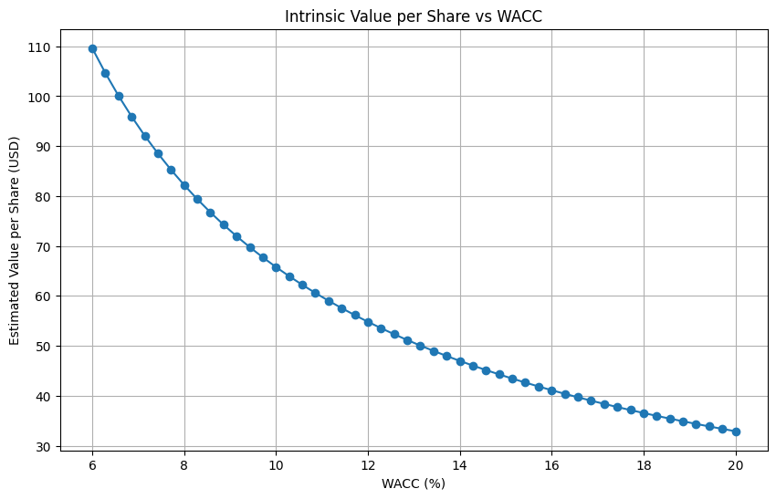

```python
import matplotlib.pyplot as plt

plt.figure(figsize=(10, 6))
plt.plot(wacc_range * 100, per_share, marker='o')
plt.title("Intrinsic Value per Share vs WACC")
plt.xlabel("WACC (%)")
plt.ylabel("Estimated Value per Share (USD)")
plt.grid(True)
plt.show()
```

## 5. Monte Carlo Simulation - 100 Simulations for Next 30 Days - Present graphical output - Interpret mean forecast and risk range

This part applies **Monte Carlo simulation** to estimate the possible future paths of Apple (AAPL) stock price over the next **30 trading days**.

- The simulation is based on **historical daily returns**, using the mean (`mu`) and standard deviation (`sigma`) of Apple’s stock returns.
- A total of **100 simulations** are generated to reflect the potential variability in price movement under a random walk model.
- This helps visualize a range of possible outcomes, reflecting **market volatility and uncertainty**, useful for **risk analysis** and **portfolio planning**.

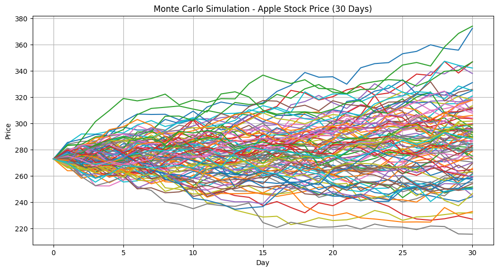

```python
days = 30
simulations = 100
last_price = apple_close.iloc[-1]
returns = apple_close.pct_change().dropna()
mu = returns.mean()
sigma = returns.std()

simulations_dict = {}
for i in range(simulations):
    prices = [last_price]
    for _ in range(days):
        shock = np.random.normal(loc=mu, scale=sigma)
        prices.append(prices[-1] * (1 + shock))
    simulations_dict[i] = prices

simulation_df = pd.DataFrame(simulations_dict)

plt.figure(figsize=(12,6))
plt.plot(simulation_df)
plt.title('Monte Carlo Simulation - Apple Stock Price (30 Days)')
plt.xlabel('Day')
plt.ylabel('Price')
plt.grid(True)
plt.show()
```

## 6.FB Prophet Forecast – Apple Stock (Next 30 Days)

> Prophet is especially useful for time-series data with strong seasonal effects, although for stock prices (which are noisy), the results should be interpreted with caution.

```python
#!pip install prophet
```

```python
# apple_df_2024_2025 = yf.download('AAPL', '2024-12-31', end='2025-12-31')

# apple_close_2024_2025 = apple_df_2024_2025['Close']
```

```
11:38:49 - cmdstanpy - INFO - Chain [1] start processing
11:38:50 - cmdstanpy - INFO - Chain [1] done processing
```

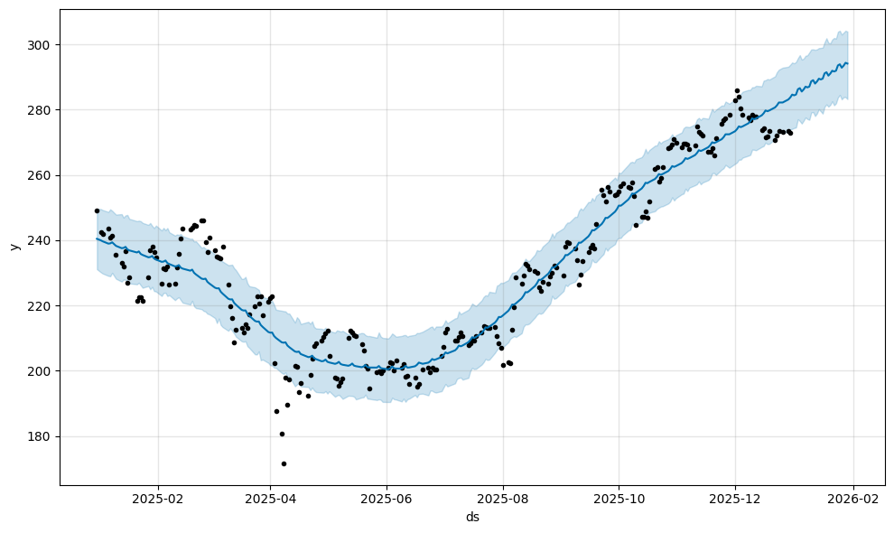

```python
from prophet import Prophet
import pandas as pd

# Prepare data: rename columns for Prophet format (ds: date, y: value)
df_prophet = apple_close_24_25.reset_index()
df_prophet.columns = ['ds', 'y']  # Prophet requires these specific column names

# Create and fit the model
model = Prophet(daily_seasonality=True)
model.fit(df_prophet)

# Forecast next 30 days
future = model.make_future_dataframe(periods=30)
forecast = model.predict(future)

# Plot the forecast
model.plot(forecast);
```

**Method**

**Results**

**Accuracy in this case**

## 7. TRADE SIGNALS - MOVING AVERAGE

This analysis uses yfinance to obtain Apple’s stock data and applies 20-day and 50-day SMAs to identify trends.

Crossover points generate trading signals: a Golden Cross indicates a potential buy opportunity, while a Death Cross suggests a potential sell signal.

The purpose is to visualize price trends and support short-term trading decisions.

```
[*********************100%***********************]  1 of 1 completed
```

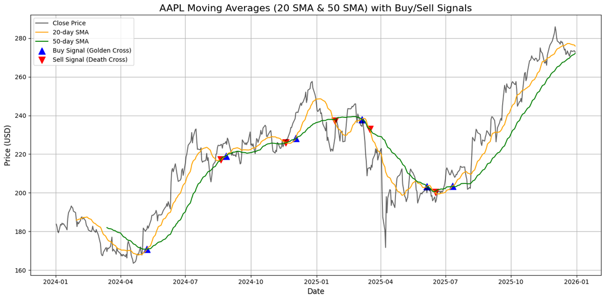

```python
# 1. Set time period (2 years up to Dec 31, 2025)

start_date = '2023-12-31'
end_date = '2025-12-31'  # end date is exclusive

# 2. Download Apple data
df = yf.download('AAPL', start=start_date, end=end_date)

# Keep only closing price
df = df[['Close']]

# 3. Calculate moving averages

df['SMA_20'] = df['Close'].rolling(window=20).mean()
df['SMA_50'] = df['Close'].rolling(window=50).mean()

# 4. Detect crossover signals

df['Signal'] = 0
df.loc[df['SMA_20'] > df['SMA_50'], 'Signal'] = 1
df.loc[df['SMA_20'] < df['SMA_50'], 'Signal'] = -1

# Find where Signal changes → crossover points
df['Crossover'] = df['Signal'].diff()

# Golden Cross (Buy) = 20 SMA crosses above 50 SMA
golden_cross = df[df['Crossover'] == 2]

# Death Cross (Sell) = 20 SMA crosses below 50 SMA
death_cross = df[df['Crossover'] == -2]

# 5. Plot chart
plt.figure(figsize=(14,7))

# Close and SMAs
plt.plot(df['Close'], label='Close Price', color='black', alpha=0.6)
plt.plot(df['SMA_20'], label='20-day SMA', color='orange')
plt.plot(df['SMA_50'], label='50-day SMA', color='green')

# Buy signals (Blue triangle at SMA intersection)
plt.scatter(golden_cross.index, (golden_cross['SMA_20'] + golden_cross['SMA_50'])/2,
            color='blue', marker='^', s=120, label='Buy Signal (Golden Cross)')

# Sell signals (Red triangle at SMA intersection)
plt.scatter(death_cross.index, (death_cross['SMA_20'] + death_cross['SMA_50'])/2,
            color='red', marker='v', s=120, label='Sell Signal (Death Cross)')

# Titles and labels
plt.title('AAPL Moving Averages (20 SMA & 50 SMA) with Buy/Sell Signals', fontsize=16)
plt.xlabel('Date', fontsize=12)
plt.ylabel('Price (USD)', fontsize=12)
plt.grid(True)
plt.legend()
plt.tight_layout()

plt.show()
```

- Uptrend: When the 20-day SMA (orange) is above the 50-day SMA (green) → price tends to rise.
- Downtrend: When the 20-day SMA is below the 50-day SMA → price tends to fall.
- Golden Cross (▲ blue): Point where the 20-day SMA crosses above the 50-day SMA → potential buy signal.
- Death Cross (▼ red): Point where the 20-day SMA crosses below the 50-day SMA → potential sell signal.

[output not shown]

## MARKET SHARE CHARTS for the Final Report

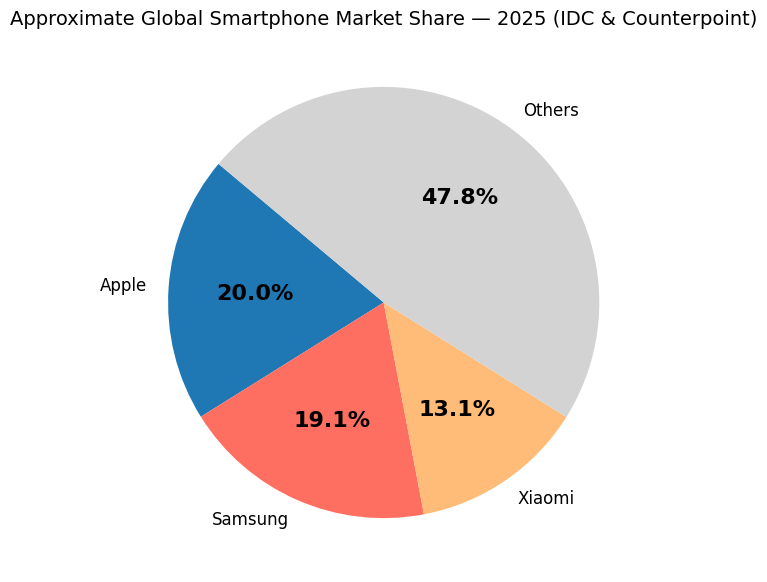

```python
import matplotlib.pyplot as plt

brands = ["Apple", "Samsung", "Xiaomi", "Others"]
shares = [20.0, 19.1, 13.1, 47.8]

colors = ["#1f77b4", "#ff6f61", "#ffbb78", "#d3d3d3"]

plt.figure(figsize=(7,7))

wedges, texts, autotexts = plt.pie(
    shares,
    labels=brands,
    colors=colors,
    autopct="%1.1f%%",
    startangle=140
)

# Tăng size label (Apple, Samsung...)
for text in texts:
    text.set_fontsize(12)

# Tăng size % (autopct)
for autotext in autotexts:
    autotext.set_fontsize(16)  # <-- chỉnh ở đây (16–20 là đẹp)
    autotext.set_weight("bold")

plt.title("Approximate Global Smartphone Market Share — 2025 (IDC & Counterpoint)", fontsize=14)

plt.show()
```

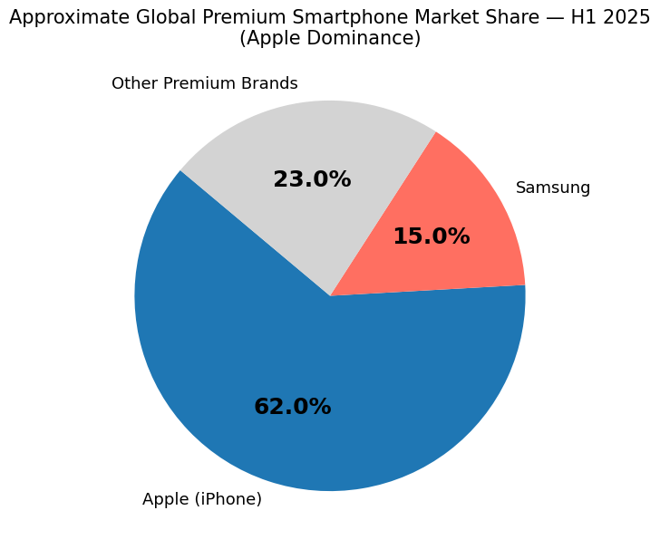

```python
import matplotlib.pyplot as plt

# Approximate premium share data (H1 2025)
brands = ["Apple (iPhone)", "Samsung", "Other Premium Brands"]
shares = [62, 15, 23]

colors = ["#1f77b4", "#ff6f61", "#d3d3d3"]

plt.figure(figsize=(7,7))

wedges, texts, autotexts = plt.pie(
    shares,
    labels=brands,
    colors=colors,
    autopct="%1.1f%%",
    startangle=140
)

# Tăng size label
for text in texts:
    text.set_fontsize(13)

# Tăng size % (to + đậm cho dễ nhìn)
for autotext in autotexts:
    autotext.set_fontsize(18)
    autotext.set_weight("bold")

plt.title(
    "Approximate Global Premium Smartphone Market Share — H1 2025\n(Apple Dominance)",
    fontsize=15
)

plt.show()
```